Part 1 can be found [here](https://maxkusnadi.github.io/whatsapp-analyzer/NERDS.html)

# Preprocessing

```python
# Importing pandas and ggplot
%matplotlib inline
import pandas as pd
import seaborn as sns
import numpy as np

sns.set_style("whitegrid")
sns.set(font_scale=1.5)

# Open the csv file
data = pd.read_csv("../data/NERDS.csv")

# Convert Date string to datetime format
data['Date'] = pd.to_datetime(data['Date'], format="%d/%m/%Y %H:%M")
```

# Most Fav Words

### Referring to this picture

[figure not shown]

#### Fav word 1.0

### It is really not meaningful as it contains stopwords. So we need to remove stopwords e.g. "gua", "gw" etc and try to impose minimum number of words

```python
# WA does not capture media (video etc) in its text file.
# Instead, all the media shared is replaced by <Media ommited>
# We have to clean it for fairness sake

# data_words = data[data['Text'] != '<Media omitted>']

# data_words['Text'].apply(str)
```

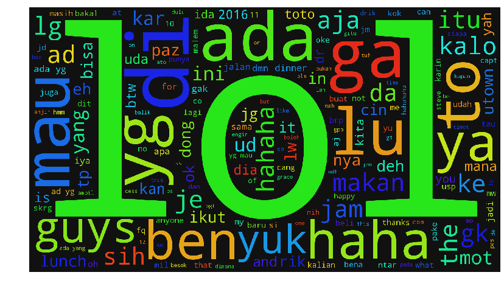

```python
from wordcloud import WordCloud
from sklearn.feature_extraction.text import CountVectorizer

vect = CountVectorizer(min_df=15, max_df=1.0, stop_words=["gua", "gw"], ngram_range=(1,3))


vect.fit(data_words['Text'])

text_dtm = vect.transform(data_words['Text'])
text_dtm

word_freq_df = pd.DataFrame({'term': vect.get_feature_names(), 'occurrences':np.asarray(text_dtm.sum(axis=0)).ravel().tolist()})

wc = WordCloud(width=1920, height=1080, scale=1,
               min_font_size=18, margin=20,
               random_state=27,
               background_color='#111')
wc.generate_from_frequencies(zip(word_freq_df['term'], word_freq_df['occurrences']))
sns.plt.figure( figsize=(16,8) )
sns.plt.axis("off")
sns.plt.imshow(wc)
```

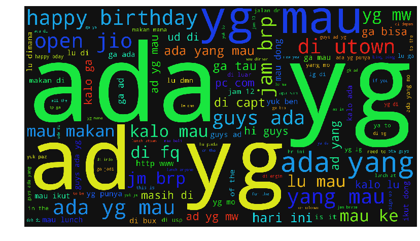

```python
vect = CountVectorizer(min_df=15, max_df=1.0, stop_words=["gua", "gw"], ngram_range=(2,3))


vect.fit(data_words['Text'])

text_dtm = vect.transform(data_words['Text'])
text_dtm

word_freq_df = pd.DataFrame({'term': vect.get_feature_names(), 'occurrences':np.asarray(text_dtm.sum(axis=0)).ravel().tolist()})

wc = WordCloud(width=1920, height=1080, scale=1,
               min_font_size=18, margin=20,
               random_state=27,
               background_color='#111')
wc.generate_from_frequencies(zip(word_freq_df['term'], word_freq_df['occurrences']))
sns.plt.figure( figsize=(16,8) )
sns.plt.axis("off")
sns.plt.imshow(wc)
```

### Interesting... Most of these phrases are questions and invitations. Let's increase the minimum no of words to 3

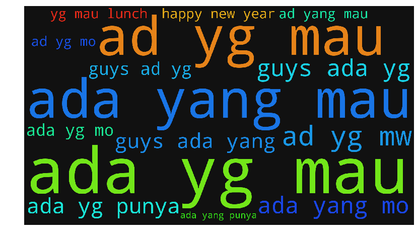

```python
vect = CountVectorizer(min_df=15, max_df=1.0, stop_words=["gua", "gw"], ngram_range=(3,3))


vect.fit(data_words['Text'])

text_dtm = vect.transform(data_words['Text'])
text_dtm

word_freq_df = pd.DataFrame({'term': vect.get_feature_names(), 'occurrences':np.asarray(text_dtm.sum(axis=0)).ravel().tolist()})

wc = WordCloud(width=1920, height=1080, scale=1,
               min_font_size=18, margin=20,
               random_state=27,
               background_color='#111')
wc.generate_from_frequencies(zip(word_freq_df['term'], word_freq_df['occurrences']))
sns.plt.figure( figsize=(16,8) )
sns.plt.axis("off")
sns.plt.imshow(wc)
```

### Hmmm... LOL. Okay let's include all these words to the stop words list

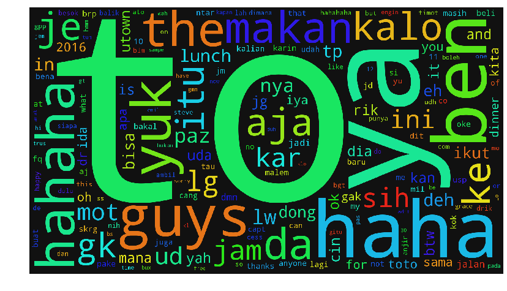

```python
vect = CountVectorizer(min_df=15, max_df=1.0, stop_words=["di", "lu", "ga", "gua", "gw", "lol", "ada", "ad", "yang", "yg", "mau", "mw", "mw"], ngram_range=(1,3))


vect.fit(data_words['Text'])

text_dtm = vect.transform(data_words['Text'])
text_dtm

word_freq_df = pd.DataFrame({'term': vect.get_feature_names(), 'occurrences':np.asarray(text_dtm.sum(axis=0)).ravel().tolist()})

wc = WordCloud(width=1920, height=1080, scale=1,
               min_font_size=18, margin=20,
               random_state=27,
               background_color='#111')
wc.generate_from_frequencies(zip(word_freq_df['term'], word_freq_df['occurrences']))
sns.plt.figure( figsize=(16,8) )
sns.plt.axis("off")
sns.plt.imshow(wc)
```

### Seems like a person whose name includes "to" is very popular. Let's see what they have if minimum words are 2

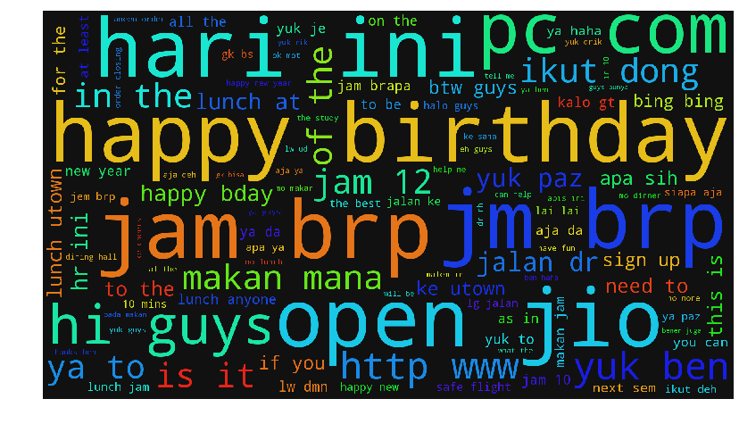

```python
vect = CountVectorizer(min_df=15, max_df=1.0, stop_words=["di", "lu", "ga", "gua", "gw", "lol", "ada", "ad", "yang", "yg", "mau", "mw", "mw"],
                       ngram_range=(2,3))


vect.fit(data_words['Text'])

text_dtm = vect.transform(data_words['Text'])
text_dtm

word_freq_df = pd.DataFrame({'term': vect.get_feature_names(), 'occurrences':np.asarray(text_dtm.sum(axis=0)).ravel().tolist()})

wc = WordCloud(width=1920, height=1080, scale=1,
               min_font_size=18, margin=20,
               random_state=27,
               background_color='#111')
wc.generate_from_frequencies(zip(word_freq_df['term'], word_freq_df['occurrences']))
sns.plt.figure( figsize=(16,8) )
sns.plt.axis("off")
sns.plt.imshow(wc)
```

### Wot.. Mostly asking time and happy birthday. Seems like pc com is the most favourite place too. 'Open jio' and 'yuk ben' may have something interesting. Let's explore more. Increase the minimum number of words to 3

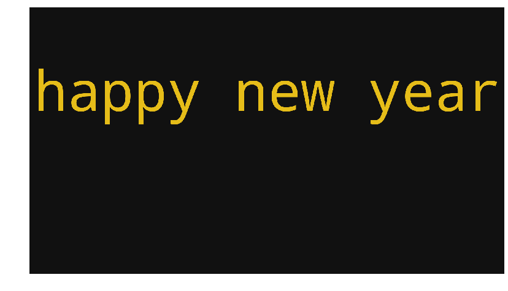

```python
vect = CountVectorizer(min_df=15, max_df=1.0, stop_words=["di", "lu", "ga", "gua", "gw", "lol", "ada", "ad", "yang", "yg", "mau", "mw", "mw"],
                       ngram_range=(3,3))


vect.fit(data_words['Text'])

text_dtm = vect.transform(data_words['Text'])
text_dtm

word_freq_df = pd.DataFrame({'term': vect.get_feature_names(), 'occurrences':np.asarray(text_dtm.sum(axis=0)).ravel().tolist()})

wc = WordCloud(width=1920, height=1080, scale=1,
               min_font_size=18, margin=20,
               random_state=27,
               background_color='#111')
wc.generate_from_frequencies(zip(word_freq_df['term'], word_freq_df['occurrences']))
sns.plt.figure( figsize=(16,8) )
sns.plt.axis("off")
sns.plt.imshow(wc)
```

### Hmm oh well.. Let's exclude all the 'asking time' questions

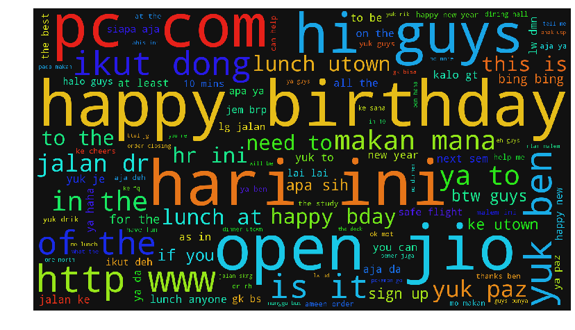

```python
vect = CountVectorizer(min_df=15, max_df=1.0, stop_words=["jam", "jm","di", "lu", "ga", "gua", "gw", "lol", "ada", "ad", "yang", "yg", "mau", "mw", "mw"],
                       ngram_range=(2,3))


vect.fit(data_words['Text'])

text_dtm = vect.transform(data_words['Text'])
text_dtm

word_freq_df = pd.DataFrame({'term': vect.get_feature_names(), 'occurrences':np.asarray(text_dtm.sum(axis=0)).ravel().tolist()})

wc = WordCloud(width=1920, height=1080, scale=1,
               min_font_size=18, margin=20,
               random_state=27,
               background_color='#111')
wc.generate_from_frequencies(zip(word_freq_df['term'], word_freq_df['occurrences']))
sns.plt.figure( figsize=(16,8) )
sns.plt.axis("off")
sns.plt.imshow(wc)
```

### If one were to generate sentences from this, it would be **'hi guys, happy birthday. open jio hari ini (di) pc com.**

## Conclusion

### - This group chat is mainly to ask questions and invite people

### - "to" is the most called name

### - PC com is mentioned the most

# What are those peaks?

### Referring to

[figure not shown]

##### Number of chats over time (month-year)

### We can see see that there are peaks around Apr-May 15 (1), Aug-Oct 15(2), Jan-Feb 16 (3) and Jul-Sep 16 (4). What were we talking then?

## Peak 1 Apr-May 2015

```python
data_words['Month_Year'] = data['Date'].apply(lambda x:x.date().strftime('%m/%Y'))
```

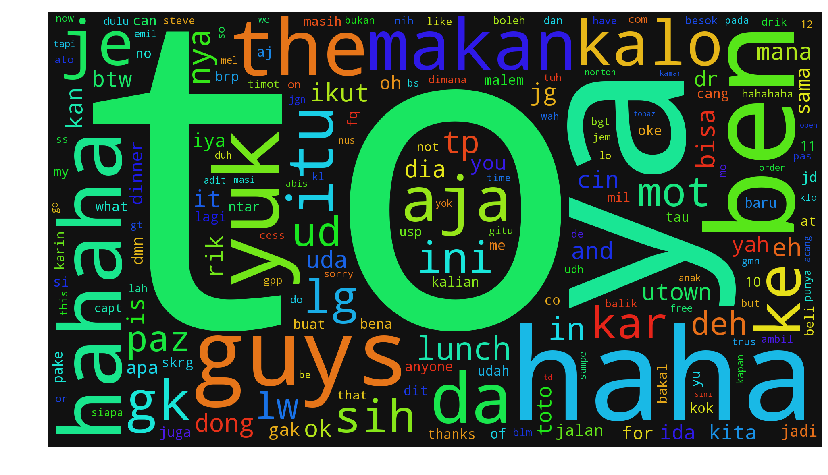

```python
vect = CountVectorizer(min_df=15, max_df=0.8, stop_words=["jam", "jm","di", "lu", "ga", "gua", "gw", "lol", "ada", "ad", "yang", "yg", "mau", "mw", "mw"],
                       ngram_range=(1,3))

vect.fit(data_words['Text'][(data_words['Month_Year'] == "04/2015") | (data_words['Month_Year'] == "05/2015")])

text_dtm = vect.transform(data_words['Text'])
text_dtm

word_freq_df = pd.DataFrame({'term': vect.get_feature_names(), 'occurrences':np.asarray(text_dtm.sum(axis=0)).ravel().tolist()})

wc = WordCloud(width=1920, height=1080, scale=1,
               min_font_size=18, margin=20,
               random_state=27,
               background_color='#111')
wc.generate_from_frequencies(zip(word_freq_df['term'], word_freq_df['occurrences']))
sns.plt.figure( figsize=(16,8) )
sns.plt.axis("off")
sns.plt.imshow(wc)
```

### Pretty similar. Let's increase minimum number of words to 2

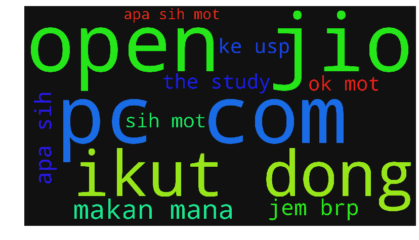

```python
vect = CountVectorizer(min_df=10, max_df=0.8, stop_words=["jam", "jm","di", "lu", "ga", "gua", "gw", "lol", "ada", "ad", "yang", "yg", "mau", "mw", "mw"],
                       ngram_range=(2,3))

vect.fit(data_words['Text'][(data_words['Month_Year'] == "04/2015") | (data_words['Month_Year'] == "05/2015")])

text_dtm = vect.transform(data_words['Text'])
text_dtm

word_freq_df = pd.DataFrame({'term': vect.get_feature_names(), 'occurrences':np.asarray(text_dtm.sum(axis=0)).ravel().tolist()})

wc = WordCloud(width=1920, height=1080, scale=1,
               min_font_size=18, margin=20,
               random_state=27,
               background_color='#111')
wc.generate_from_frequencies(zip(word_freq_df['term'], word_freq_df['occurrences']))
sns.plt.figure( figsize=(16,8) )
sns.plt.axis("off")
sns.plt.imshow(wc)
```

### Open jio pc com? Hmm... Exam period maybe. Notable findings : apa sih mot

## Peak 2 Aug-Oct 2015

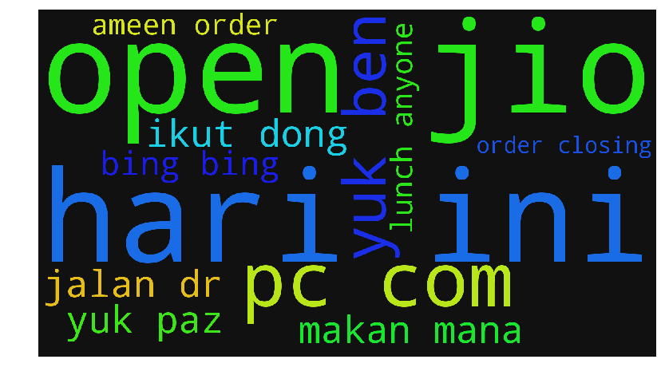

```python
vect = CountVectorizer(min_df=10, max_df=0.8, stop_words=["jam", "jm","di", "lu", "ga", "gua", "gw", "lol", "ada", "ad", "yang", "yg", "mau", "mw", "mw"],
                       ngram_range=(2,3))

vect.fit(data_words['Text'][(data_words['Month_Year'] == "08/2015") | (data_words['Month_Year'] == "09/2015") | (data_words['Month_Year'] == "10/2015")])

text_dtm = vect.transform(data_words['Text'])
text_dtm

word_freq_df = pd.DataFrame({'term': vect.get_feature_names(), 'occurrences':np.asarray(text_dtm.sum(axis=0)).ravel().tolist()})

wc = WordCloud(width=1920, height=1080, scale=1,
               min_font_size=18, margin=20,
               random_state=27,
               background_color='#111')
wc.generate_from_frequencies(zip(word_freq_df['term'], word_freq_df['occurrences']))
sns.plt.figure( figsize=(16,8) )
sns.plt.axis("off")
sns.plt.imshow(wc)
```

### Peak period for open jio, makan mana, ameen order and bing bing. Thought provoking. But still pc com

## Peak 3 Jan-Feb 2016

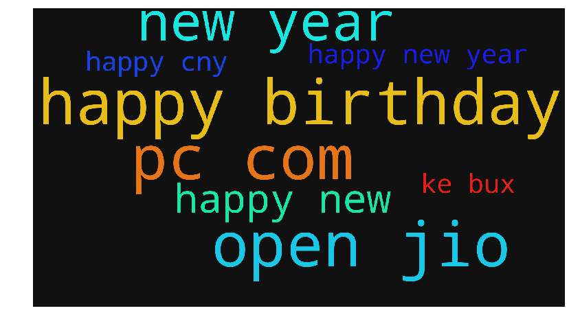

```python
vect = CountVectorizer(min_df=8, max_df=0.8, stop_words=["jam", "jm","di", "lu", "ga", "gua", "gw", "lol", "ada", "ad", "yang", "yg", "mau", "mw", "mw"],
                       ngram_range=(2,3))

vect.fit(data_words['Text'][(data_words['Month_Year'] == "01/2016") | (data_words['Month_Year'] == "02/2016")])

text_dtm = vect.transform(data_words['Text'])
text_dtm

word_freq_df = pd.DataFrame({'term': vect.get_feature_names(), 'occurrences':np.asarray(text_dtm.sum(axis=0)).ravel().tolist()})

wc = WordCloud(width=1920, height=1080, scale=1,
               min_font_size=18, margin=20,
               random_state=27,
               background_color='#111')
wc.generate_from_frequencies(zip(word_freq_df['term'], word_freq_df['occurrences']))
sns.plt.figure( figsize=(16,8) )
sns.plt.axis("off")
sns.plt.imshow(wc)
```

### CNY and new year. open jio is still there. Unsuprisingly, pc com too

# Peak 4 July-Sept 16

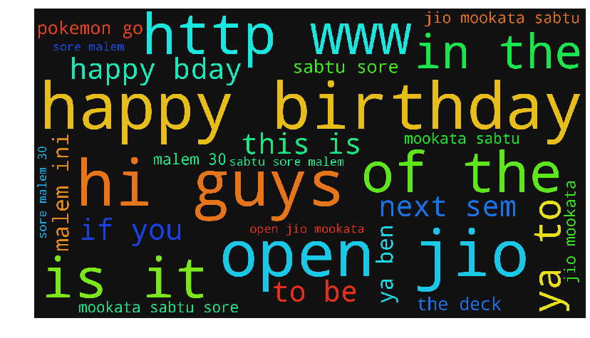

```python
vect = CountVectorizer(min_df=10, max_df=0.8, stop_words=["jam", "jm","di", "lu", "ga", "gua", "gw", "lol", "ada", "ad", "yang", "yg", "mau", "mw", "mw"],
                       ngram_range=(2,3))

vect.fit(data_words['Text'][(data_words['Month_Year'] == "07/2016") | (data_words['Month_Year'] == "08/2016") | (data_words['Month_Year'] == "09/2016")])

text_dtm = vect.transform(data_words['Text'])
text_dtm

word_freq_df = pd.DataFrame({'term': vect.get_feature_names(), 'occurrences':np.asarray(text_dtm.sum(axis=0)).ravel().tolist()})

wc = WordCloud(width=1920, height=1080, scale=1,
               min_font_size=18, margin=20,
               random_state=27,
               background_color='#111')
wc.generate_from_frequencies(zip(word_freq_df['term'], word_freq_df['occurrences']))
sns.plt.figure( figsize=(16,8) )
sns.plt.axis("off")
sns.plt.imshow(wc)
```

### Hmm open jio mookata sabtu sore seemed to be the trending topic back then. Seems we had a surge in birthday celebration as well

# It's High Noon...

### Referring to

[figure not shown]

#### Number of chats over time (hour)

### We can see 3 peaks again, 12pm (1), 5-7pm (2), 10-11pm (3). What happen during **high noon**?

# Peak 1 (12 pm)

```python
data_words['Hour'] = data_words['Date'].apply(lambda x:x.time().strftime('%H'))
```

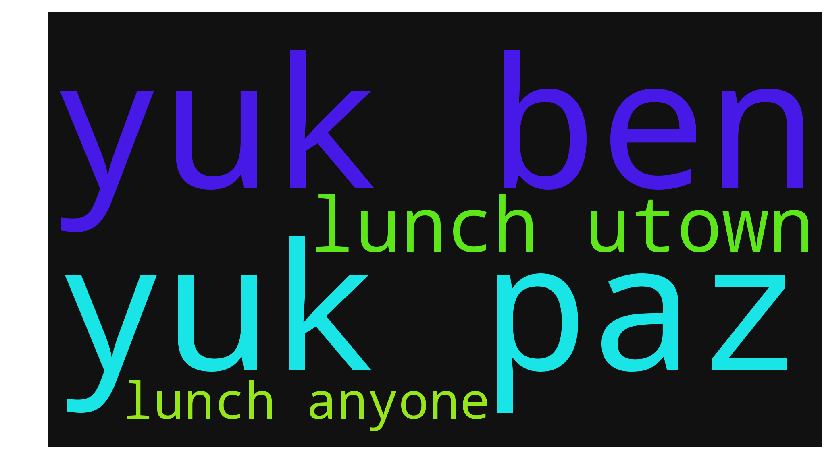

```python
vect = CountVectorizer(min_df=10, max_df=0.8, stop_words=["jam", "jm","di", "lu", "ga", "gua", "gw", "lol", "ada", "ad", "yang", "yg", "mau", "mw", "mw"],
                       ngram_range=(2,3))

vect.fit(data_words['Text'][(data_words['Hour'] == "12")])

text_dtm = vect.transform(data_words['Text'])
text_dtm

word_freq_df = pd.DataFrame({'term': vect.get_feature_names(), 'occurrences':np.asarray(text_dtm.sum(axis=0)).ravel().tolist()})

wc = WordCloud(width=1920, height=1080, scale=1,
               min_font_size=18, margin=20,
               random_state=27,
               background_color='#111')
wc.generate_from_frequencies(zip(word_freq_df['term'], word_freq_df['occurrences']))
sns.plt.figure( figsize=(16,8) )
sns.plt.axis("off")
sns.plt.imshow(wc)
```

### Possible convo:

### Bena: "lunch anyone?"

### Topaz: "yuk ben. lunch utown?"

### Bena: "yuk paz"

# Peak 2 (5-7 pm)

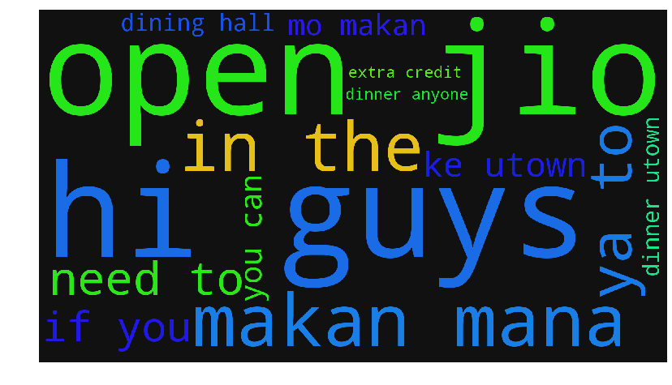

```python
vect = CountVectorizer(min_df=10, max_df=0.8, stop_words=["jam", "jm","di", "lu", "ga", "gua", "gw", "lol", "ada", "ad", "yang", "yg", "mau", "mw", "mw"],
                       ngram_range=(2,3))

vect.fit(data_words['Text'][(data_words['Hour'] == "17") | (data_words['Hour'] == "18") | (data_words['Hour'] == "19")])

text_dtm = vect.transform(data_words['Text'])
text_dtm

word_freq_df = pd.DataFrame({'term': vect.get_feature_names(), 'occurrences':np.asarray(text_dtm.sum(axis=0)).ravel().tolist()})

wc = WordCloud(width=1920, height=1080, scale=1,
               min_font_size=18, margin=20,
               random_state=27,
               background_color='#111')
wc.generate_from_frequencies(zip(word_freq_df['term'], word_freq_df['occurrences']))
sns.plt.figure( figsize=(16,8) )
sns.plt.axis("off")
sns.plt.imshow(wc)
```

### Open jio makan mana. Why is there 'if you'?

# Peak 3 (10-11pm)

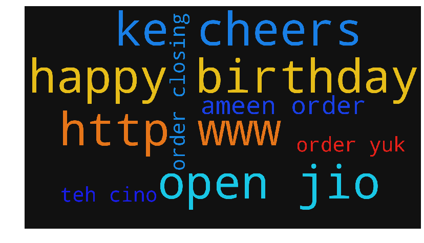

```python
vect = CountVectorizer(min_df=8, max_df=0.8, stop_words=["jam", "jm","di", "lu", "ga", "gua", "gw", "lol", "ada", "ad", "yang", "yg", "mau", "mw", "mw"],
                       ngram_range=(2,3))

vect.fit(data_words['Text'][(data_words['Hour'] == "22") | (data_words['Hour'] == "23")])

text_dtm = vect.transform(data_words['Text'])
text_dtm

word_freq_df = pd.DataFrame({'term': vect.get_feature_names(), 'occurrences':np.asarray(text_dtm.sum(axis=0)).ravel().tolist()})

wc = WordCloud(width=1920, height=1080, scale=1,
               min_font_size=18, margin=20,
               random_state=27,
               background_color='#111')
wc.generate_from_frequencies(zip(word_freq_df['term'], word_freq_df['occurrences']))
sns.plt.figure( figsize=(16,8) )
sns.plt.axis("off")
sns.plt.imshow(wc)
```

### Fav order from ameen: **teh cino**. People are going to cheers too

# Who says what?

### Referring to

[figure not shown]

#### 10 Most active members

### What were those people saying? Let's explore

# Karin

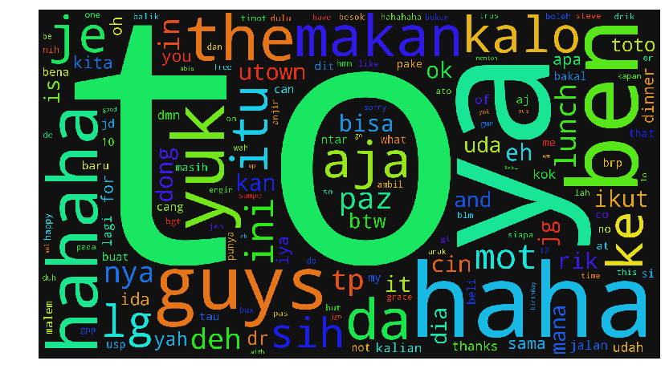

```python
vect = CountVectorizer(min_df=10, max_df=1.0, stop_words=["jam", "jm","di", "lu", "ga", "gua", "gw", "lol", "ada", "ad", "yang", "yg", "mau", "mw", "mw"],
                       ngram_range=(1,3))

vect.fit(data_words['Text'][(data_words['Name'] == "Karin")])

text_dtm = vect.transform(data_words['Text'])
text_dtm

word_freq_df = pd.DataFrame({'term': vect.get_feature_names(), 'occurrences':np.asarray(text_dtm.sum(axis=0)).ravel().tolist()})

wc = WordCloud(width=1920, height=1080, scale=1,
               min_font_size=18, margin=20,
               random_state=27,
               background_color='#111')
wc.generate_from_frequencies(zip(word_freq_df['term'], word_freq_df['occurrences']))
sns.plt.figure( figsize=(16,8) )
sns.plt.axis("off")
sns.plt.imshow(wc)
```

### to? Let's increase the minimum number of words

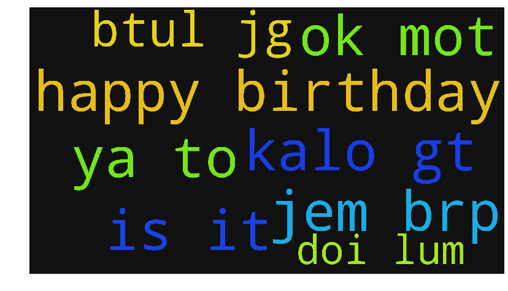

```python
vect = CountVectorizer(min_df=10, max_df=1.0, stop_words=["jam", "jm","di", "lu", "ga", "gua", "gw", "lol", "ada", "ad", "yang", "yg", "mau", "mw", "mw"],
                       ngram_range=(2,3))

vect.fit(data_words['Text'][(data_words['Name'] == "Karin")])

text_dtm = vect.transform(data_words['Text'])
text_dtm

word_freq_df = pd.DataFrame({'term': vect.get_feature_names(), 'occurrences':np.asarray(text_dtm.sum(axis=0)).ravel().tolist()})

wc = WordCloud(width=1920, height=1080, scale=1,
               min_font_size=18, margin=20,
               random_state=27,
               background_color='#111')
wc.generate_from_frequencies(zip(word_freq_df['term'], word_freq_df['occurrences']))
sns.plt.figure( figsize=(16,8) )
sns.plt.axis("off")
sns.plt.imshow(wc)
```

### ok mot

# Benaya

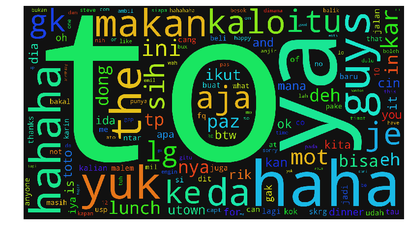

```python
vect = CountVectorizer(min_df=10, max_df=1.0, stop_words=["jam", "jm","di", "lu", "ga", "gua", "gw", "lol", "ada", "ad", "yang", "yg", "mau", "mw", "mw"],
                       ngram_range=(1,3))

vect.fit(data_words['Text'][(data_words['Name'] == "Benaya")])

text_dtm = vect.transform(data_words['Text'])
text_dtm

word_freq_df = pd.DataFrame({'term': vect.get_feature_names(), 'occurrences':np.asarray(text_dtm.sum(axis=0)).ravel().tolist()})

wc = WordCloud(width=1920, height=1080, scale=1,
               min_font_size=18, margin=20,
               random_state=27,
               background_color='#111')
wc.generate_from_frequencies(zip(word_freq_df['term'], word_freq_df['occurrences']))
sns.plt.figure( figsize=(16,8) )
sns.plt.axis("off")
sns.plt.imshow(wc)
```

### to again????

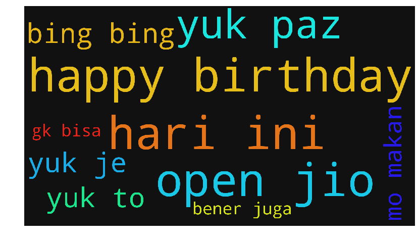

```python
vect = CountVectorizer(min_df=10, max_df=1.0, stop_words=["jam", "jm","di", "lu", "ga", "gua", "gw", "lol", "ada", "ad", "yang", "yg", "mau", "mw", "mw"],
                       ngram_range=(2,3))

vect.fit(data_words['Text'][(data_words['Name'] == "Benaya")])

text_dtm = vect.transform(data_words['Text'])
text_dtm

word_freq_df = pd.DataFrame({'term': vect.get_feature_names(), 'occurrences':np.asarray(text_dtm.sum(axis=0)).ravel().tolist()})

wc = WordCloud(width=1920, height=1080, scale=1,
               min_font_size=18, margin=20,
               random_state=27,
               background_color='#111')
wc.generate_from_frequencies(zip(word_freq_df['term'], word_freq_df['occurrences']))
sns.plt.figure( figsize=(16,8) )
sns.plt.axis("off")
sns.plt.imshow(wc)
```

# Toto

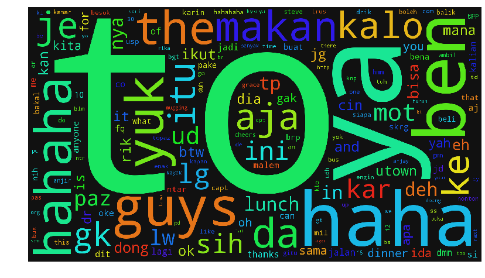

```python
vect = CountVectorizer(min_df=10, max_df=1.0, stop_words=["jam", "jm","di", "lu", "ga", "gua", "gw", "lol", "ada", "ad", "yang", "yg", "mau", "mw", "mw"],
                       ngram_range=(1,3))

vect.fit(data_words['Text'][(data_words['Name'] == "Toto")])

text_dtm = vect.transform(data_words['Text'])
text_dtm

word_freq_df = pd.DataFrame({'term': vect.get_feature_names(), 'occurrences':np.asarray(text_dtm.sum(axis=0)).ravel().tolist()})

wc = WordCloud(width=1920, height=1080, scale=1,
               min_font_size=18, margin=20,
               random_state=27,
               background_color='#111')
wc.generate_from_frequencies(zip(word_freq_df['term'], word_freq_df['occurrences']))
sns.plt.figure( figsize=(16,8) )
sns.plt.axis("off")
sns.plt.imshow(wc)
```

### Even toto calling to the most. Prolly it's the english word 'to'. Nobody knows

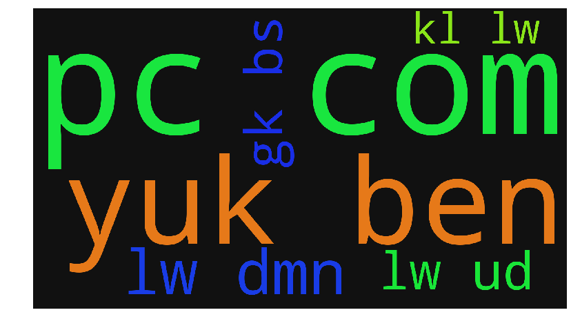

```python
vect = CountVectorizer(min_df=10, max_df=1.0, stop_words=["jam", "jm","di", "lu", "ga", "gua", "gw", "lol", "ada", "ad", "yang", "yg", "mau", "mw", "mw"],
                       ngram_range=(2,3))

vect.fit(data_words['Text'][(data_words['Name'] == "Toto")])

text_dtm = vect.transform(data_words['Text'])
text_dtm

word_freq_df = pd.DataFrame({'term': vect.get_feature_names(), 'occurrences':np.asarray(text_dtm.sum(axis=0)).ravel().tolist()})

wc = WordCloud(width=1920, height=1080, scale=1,
               min_font_size=18, margin=20,
               random_state=27,
               background_color='#111')
wc.generate_from_frequencies(zip(word_freq_df['term'], word_freq_df['occurrences']))
sns.plt.figure( figsize=(16,8) )
sns.plt.axis("off")
sns.plt.imshow(wc)
```

### pc com... hmm now we know where all the 'pc com' comes from

# Ida

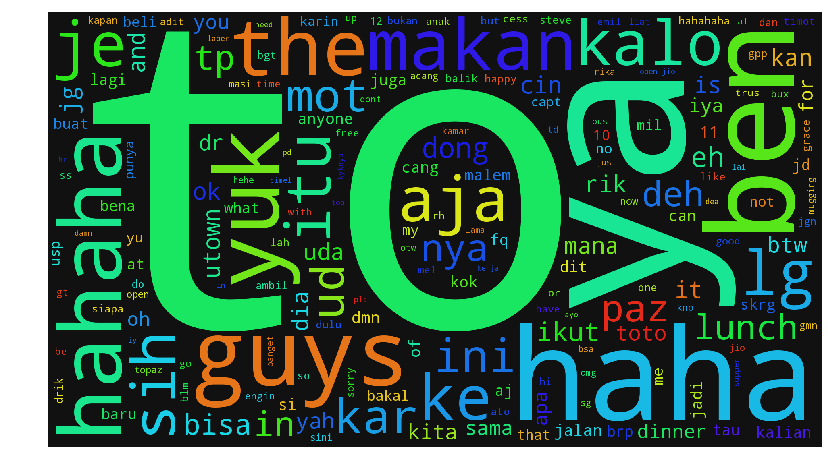

```python
vect = CountVectorizer(min_df=10, max_df=1.0, stop_words=["jam", "jm","di", "lu", "ga", "gua", "gw", "lol", "ada", "ad", "yang", "yg", "mau", "mw", "mw"],
                       ngram_range=(1,3))

vect.fit(data_words['Text'][(data_words['Name'] == "Ida")])

text_dtm = vect.transform(data_words['Text'])
text_dtm

word_freq_df = pd.DataFrame({'term': vect.get_feature_names(), 'occurrences':np.asarray(text_dtm.sum(axis=0)).ravel().tolist()})

wc = WordCloud(width=1920, height=1080, scale=1,
               min_font_size=18, margin=20,
               random_state=27,
               background_color='#111')
wc.generate_from_frequencies(zip(word_freq_df['term'], word_freq_df['occurrences']))
sns.plt.figure( figsize=(16,8) )
sns.plt.axis("off")
sns.plt.imshow(wc)
```

### Ok enough of 'to'. Let's just focus on 2 words or more

[figure not shown]

```python
vect = CountVectorizer(min_df=10, max_df=1.0, stop_words=["jam", "jm","di", "lu", "ga", "gua", "gw", "lol", "ada", "ad", "yang", "yg", "mau", "mw", "mw"],
                       ngram_range=(2,3))

vect.fit(data_words['Text'][(data_words['Name'] == "Ida")])

text_dtm = vect.transform(data_words['Text'])
text_dtm

word_freq_df = pd.DataFrame({'term': vect.get_feature_names(), 'occurrences':np.asarray(text_dtm.sum(axis=0)).ravel().tolist()})

wc = WordCloud(width=1920, height=1080, scale=1,
               min_font_size=18, margin=20,
               random_state=27,
               background_color='#111')
wc.generate_from_frequencies(zip(word_freq_df['term'], word_freq_df['occurrences']))
sns.plt.figure( figsize=(16,8) )
sns.plt.axis("off")
sns.plt.imshow(wc)
```

### Open jio hr ni. Hmm ok

# Jason

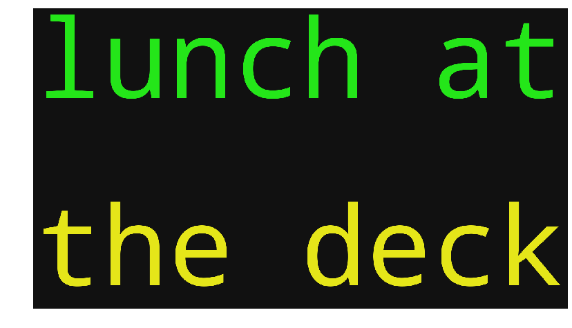

```python
vect = CountVectorizer(min_df=10, max_df=1.0, stop_words=["jam", "jm","di", "lu", "ga", "gua", "gw", "lol", "ada", "ad", "yang", "yg", "mau", "mw", "mw"],
                       ngram_range=(2,3))

vect.fit(data_words['Text'][(data_words['Name'] == "Jason")])

text_dtm = vect.transform(data_words['Text'])
text_dtm

word_freq_df = pd.DataFrame({'term': vect.get_feature_names(), 'occurrences':np.asarray(text_dtm.sum(axis=0)).ravel().tolist()})

wc = WordCloud(width=1920, height=1080, scale=1,
               min_font_size=18, margin=20,
               random_state=27,
               background_color='#111')
wc.generate_from_frequencies(zip(word_freq_df['term'], word_freq_df['occurrences']))
sns.plt.figure( figsize=(16,8) )
sns.plt.axis("off")
sns.plt.imshow(wc)
```

### Wooooooot. Lunch at the deck?

# Topaz (last)

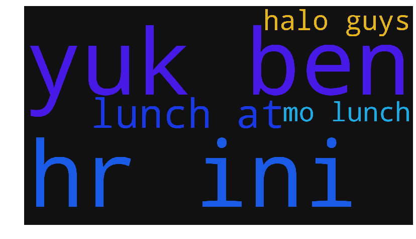

```python
vect = CountVectorizer(min_df=10, max_df=1.0, stop_words=["jam", "jm","di", "lu", "ga", "gua", "gw", "lol", "ada", "ad", "yang", "yg", "mau", "mw", "mw"],
                       ngram_range=(2,3))

vect.fit(data_words['Text'][(data_words['Name'] == "Topaz")])

text_dtm = vect.transform(data_words['Text'])
text_dtm

word_freq_df = pd.DataFrame({'term': vect.get_feature_names(), 'occurrences':np.asarray(text_dtm.sum(axis=0)).ravel().tolist()})

wc = WordCloud(width=1920, height=1080, scale=1,
               min_font_size=18, margin=20,
               random_state=27,
               background_color='#111')
wc.generate_from_frequencies(zip(word_freq_df['term'], word_freq_df['occurrences']))
sns.plt.figure( figsize=(16,8) )
sns.plt.axis("off")
sns.plt.imshow(wc)
```

### Lunch with Bena. Proving earlier convo

## How bout me?

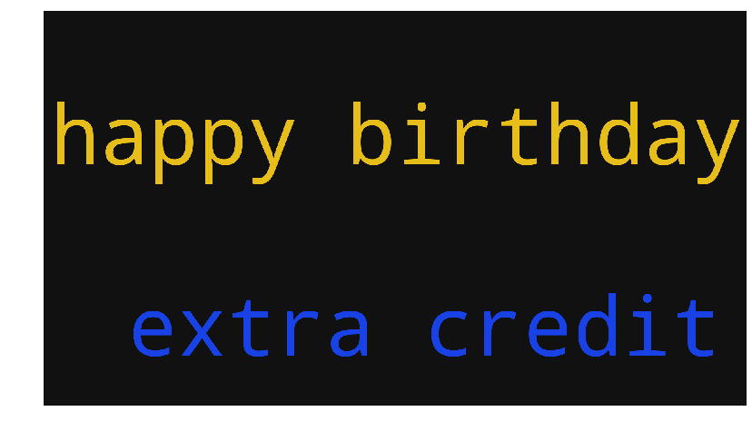

```python
vect = CountVectorizer(min_df=5, max_df=1.0, stop_words=["jam", "jm","di", "lu", "ga", "gua", "gw", "lol", "ada", "ad", "yang", "yg", "mau", "mw", "mw"],
                       ngram_range=(2,3))

vect.fit(data_words['Text'][(data_words['Name'] == "Max K")])

text_dtm = vect.transform(data_words['Text'])
text_dtm

word_freq_df = pd.DataFrame({'term': vect.get_feature_names(), 'occurrences':np.asarray(text_dtm.sum(axis=0)).ravel().tolist()})

wc = WordCloud(width=1920, height=1080, scale=1,
               min_font_size=18, margin=20,
               random_state=27,
               background_color='#111')
wc.generate_from_frequencies(zip(word_freq_df['term'], word_freq_df['occurrences']))
sns.plt.figure( figsize=(16,8) )
sns.plt.axis("off")
sns.plt.imshow(wc)
```

### Oh well...